# 1 Multilevel Models

### 1.1 Multilevel Models

Multilevel modeling is a generalization of regression methods.

Used for a variety of purposes, including prediction, data reduction, and causal inference.

From experiments and observational studies.

### 1.2 Hierarchical Data

Data structures are often hierarchical or “nested”

Examples:

- Children nested within classrooms
- Data points nested within people
- Employees nested within organizations
- Patients nested within hospitals
- Patients nested within doctors nested within clinics

### 1.3 Multilevel Models

Many names for similar models, analyses, and goals:

Multi-level model

Random effects model

Mixed model

Random coefficient model

Hierarchical model

Multilevel models are extensions of regression.

### 1.4 A Two-Level Hierarchy

| Level 2 | Class 1 | Class 2 | Class 3 | Class 4 | Class 5 | Class 6 | … | Class n |
| --- | --- | --- | --- | --- | --- | --- | --- | --- |
| Level 1 | Child 1 | Child 9 | Child 13 | Child 20 | Child 28 | Child 33 | … | Child a |
|  | Child 2 | Child 10 | Child 14 | Child 21 | Child 29 | Child 34 | … | Child b |
|  | Child 3 | Child 11 | Child 15 | Child 22 | Child 30 | Child 35 | … | Child c |
|  | Child 4 | Child 12 | Child 16 | Child 23 | Child 31 | Child 36 | … | Child d |
|  | Child 5 |  | Child 17 | Child 24 | Child 32 | Child 37 | … | Child e |
|  | Child 6 |  | Child 18 | Child 25 |  | Child 38 | … |  |
|  | Child 7 |  | Child 19 | Child 26 |  |  | … |  |
|  | Child 8 |  |  | Child 27 |  |  | … |  |

*Table 1.4.1*

### 1.5 A Three-Level Hierarchy

[output not shown]

*Table 1.4.2*

### 1.6 Radon Example

I use an example from Gelman’s book: “Data Analysis Using Regression and Multilevel/Hierarchal Models”

Document the strengths and limitations of multilevel modeling.

### 1.7 Background

Effect of city-level policies on enforcing child support payments from unmarried fathers.

Treatment is at the group (city) level.

Outcome is measured on the individual family label.

### 1.8 Benefits of Multilevel Models

Homogeneity of regression slopes

- Model the variability in regression slopes

Assumption of independence

- You can model the relationships between cases
- (Regression for repeated observations)

Missing data

- MLMs can cope with missing data

### 1.9 An Example: Cosmetic Surgery

Post_QoL

- This is a measure of quality of life after the cosmetic surgery.

Base_QoL

- Quality of life before the surgery.

Surgery

- A dummy variable that specifies whether the person has undergone cosmetic surgery (1) or whether they are on the waiting list (0).

Clinic

- Which of 10 clinics the person attended to have their surgery.

Age

- The person’s age in years.

BDI

- Natural levels of depression measured using the Beck Depression Inventory (BDI).

Reason

- This dummy variable specifies whether the person had/is waiting to have surgery purely to change their appearance (0), or because of a physical reason (1).

Gender

- Whether the person was a man (1) or a woman (0).

### 1.10 Fixed vs. Random Coefficients

Intercepts and slopes can be fixed or random

- In OLS regression they are fixed

Fixed coefficients

- Intercepts/slopes are assumed to be the same across different contexts

Random coefficients

- Intercepts/slopes are allowed to vary across different contexts

### 1.11 Fixed Slope, Random Intercept

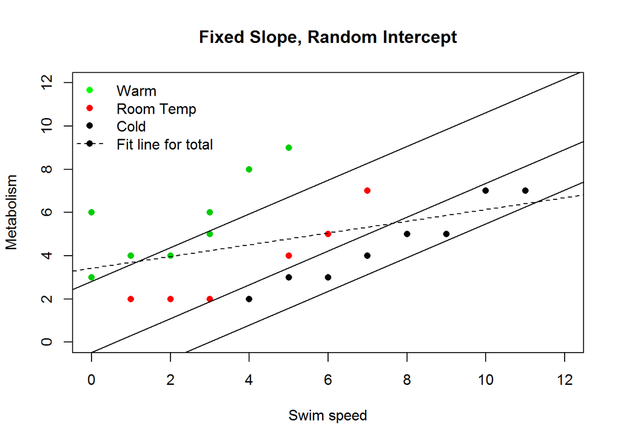

*Figure 1.11.1*

### 1.12 Random Slope, Fixed Intercept

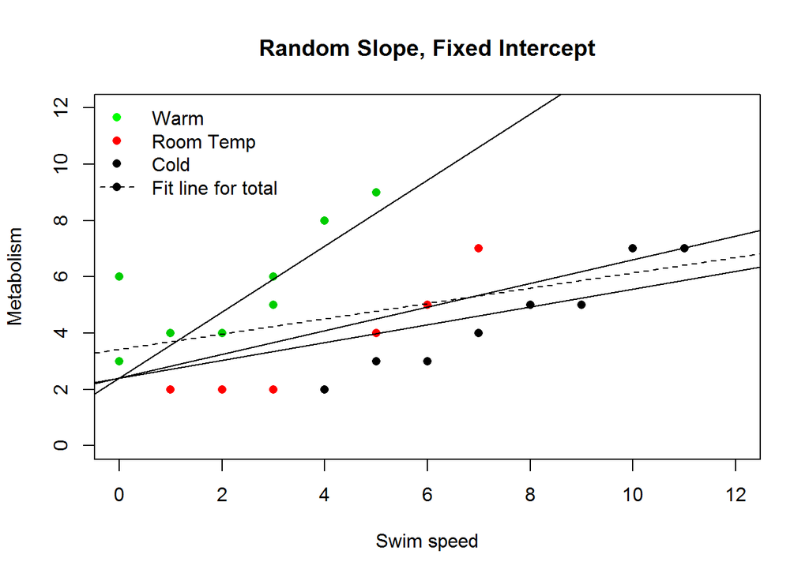

*Figure 1.12.1*

### 1.13 Random Slope, Random Intercept

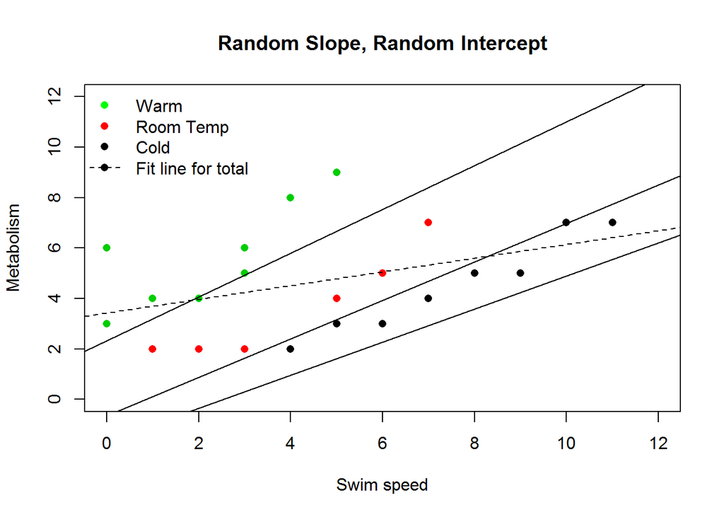

*Figure 1.13.1*

### 1.14 How to Represent These Models

Fixed intercepts and slopes

QoL after Surgery<sub>i</sub> =$b_0+b_1Sugery_i+\varepsilon_i$

Random intercepts and fixed slopes

$Y_{ij}=b_{0j}+b_1X_{ij}+\varepsilon_{ij}$

$b_{0j}=b_0+u_{0j}$

Fixed intercepts and random slopes

$Y_{ij}=b_{oi}+b_{1j}X{ij}+\varepsilon{ij}$

$b_{1j}=b_1+u_{1j}$

Random intercepts and random slopes

$Y_{ij}=b_{oi}+b_{1j}X{ij}+\varepsilon{ij}$

$b_{0j}=b_0+u_{0j}$

$b_{1j}=b_1+u_{1j}$

### 1.15 The Surgery Example

Fixed intercepts and slopes

QoL after Surgery<sub>i</sub> =$b_0+b_1Sugery_i+\varepsilon_i$

Random intercepts and random slopes

QoL After<sub>ij</sub>=$b_{0j}+b_{1j}Surgery_{ij}+b_2QoL \ Before_{ij}+\varepsilon_{ij}$

$b_{0j}=b_0+u_{0j}$

$b_{0j}=b_0+u_{0j}$

### 1.16 Comparing Models

Models should be built up gradually

- Start with fixed coefficients
- Change one aspect of the model and compare to the previous with the change in the -2LL

Assessing fit

- AIC
- BIC

### 1.17 Covariance Structures

Variance components

- Random effects are independent with similar variances Diagonal
- Random effects are independent with different variances

AR(1)

- Random effects are related with data points closer in time being more similar than those distant in time
- Variances of random effects are similar

Unstructured

+Covariances and variances of random effects are unpredictable

### 1.18 Centering

Grand mean centering

- Take each score and subtract from it the mean of all scores (for that variable)

Group mean centering

- Take each score and subtract from it the mean of scores from the same group (for that variable)

Effects of centering in multilevel models

- The effects are complicated
- Models using centred variables tend to be more stable
- It can help with problems of multicollinearity

### 1.19 Picturing the Data

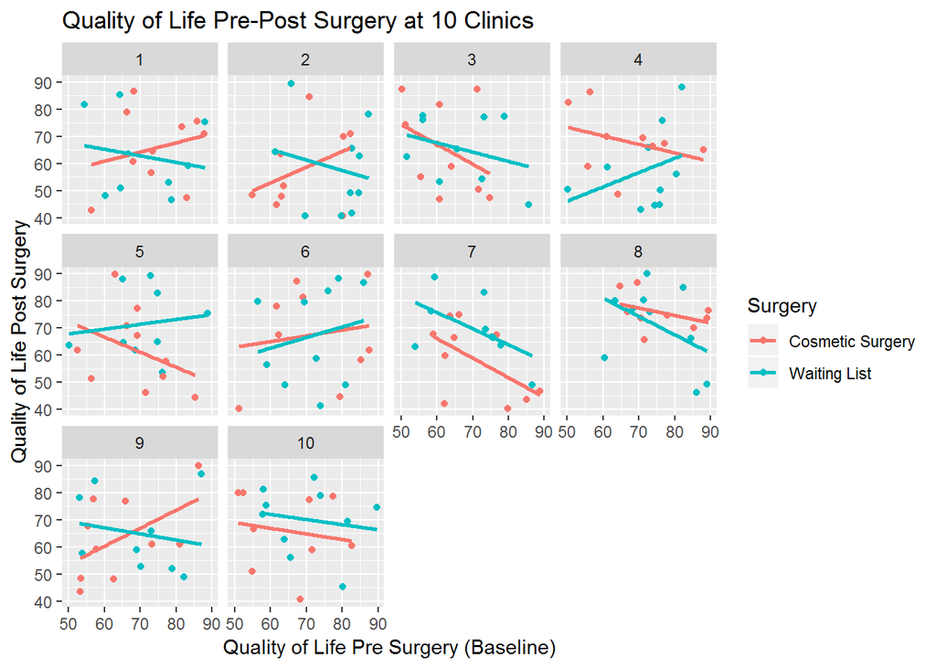

*Figure 1.19.1*

### 1.20 Compare Models

We can have a look at how the fit of the models has improved using the anova() function that we used before; the following will compare all three models that we have so far fitted):

- anova(randomInterceptOnly
- randomInterceptSurgery
- randomInterceptSurgeryQoL)

| Model | df | AIC | BIC | LogLik | Test | L.Ratio | p-value |
| --- | --- | --- | --- | --- | --- | --- | --- |
| 1 | 3 | 1911.473 | 1922.334 | -952.7364 |  |  |  |
| 2 | 4 | 1910.137 | 1924.619 | -951.0686 | 1 vs 2 | 3.33564 | 0.0678 |
| 3 | 5 | 1847.490 | 1865.592 | -918.7450 | 2 vs 3 | 64.64721 | <.0001 |

*Table 1.20.1: Comparing three models*

### 1.21 An Example: The `Honeymoon Period’

Speed dating event

- After a speed dating event data were collected on all people who ended up in a relationship with the person that they met on the speed dating night.
- None of the people measured were in the same relationship.

Satisfaction_Baseline

Satisfaction_6_Months

Satisfaction_12_Months

Satisfaction_18_Months

Gender

### 1.22 The Data

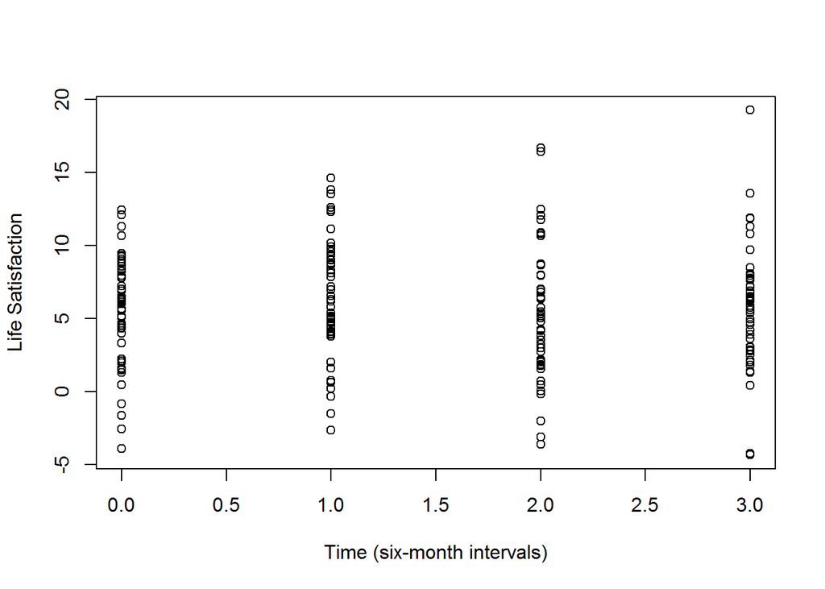

*Figure 1.22.1*

### 1.23 Restructuring Data

Data entry for multilevel models . Need the variable Time to be represented by a single column. We refer to this format as the ‘long’ format. As such we need to restructure the data.

But, in repeated measures designs we’re used to entering data so that instances of the outcome appear in different columns.

### 1.24 Introducing Random Slopes

We use the update() function to create a new model (called timeRS) which is identical to the previous model (timeRI) but updates the random part of the model to be random = ~Time|Person:

- timeRS<-update(timeRI, random = ~Time|Person)

### 1.25 To Sum Up

Data can be hierarchical and this hierarchical structure can be important.

- Most of the tests that you learn simply ignore the hierarchy.

Hierarchical models are just a fancy regression in which you can estimate the variability in the slopes and intercepts within entities.

- Slopes and intercepts can be random variables (allowed to vary) rather than fixed (assumed to be equal in different situations).

Start with a model that ignores the hierarchy and then add in random intercepts and slopes to see if they improve the fit of the model.

Growth curves model trends in the data over time

- These trends can also have variable intercepts and slopes.